# 20240922_Statistical_tests

2024-09-28

### Data import and pre-processing

Firstly, we load the example data of diarrhea related samples.

In total, 3291 samples were extracted with their relative abundance data.

### Alpha diversity comparison and statistical test of composition profile

We compare the alpha diversity of different age categories and test if they are significant different *via* **Pairwise Wilcox test**.

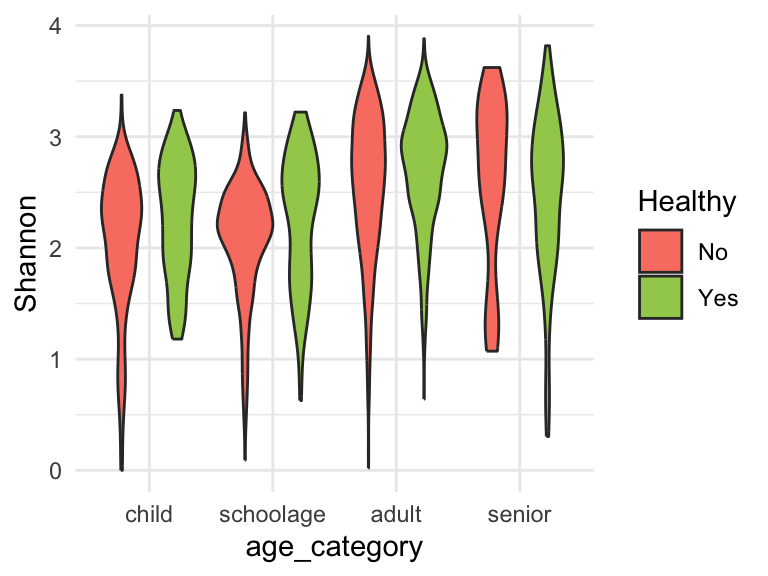

```
##
##  Welch Two Sample t-test
##
## data:  alpha_child and alpha_school
## t = 0.45232, df = 607.53, p-value = 0.6512
## alternative hypothesis: true difference in means is not equal to 0
## 95 percent confidence interval:
##  -0.06104322  0.09757700
## sample estimates:
## mean of x mean of y
##  2.125376  2.107109
```

```
##
##  Pairwise comparisons using t tests with pooled SD
##
## data:  alpha and metadata$age_category
##
##           adult   child   schoolage
## child     < 2e-16 -       -
## schoolage < 2e-16 0.670   -
## senior    0.071   5.4e-14 < 2e-16
##
## P value adjustment method: holm
```

```
##
##  Pairwise comparisons using Wilcoxon rank sum test with continuity correction
##
## data:  alpha and metadata$age_category
##
##           adult   child   schoolage
## child     < 2e-16 -       -
## schoolage < 2e-16 0.52    -
## senior    0.52    1.2e-13 < 2e-16
##
## P value adjustment method: holm
```

```
##
##  Pairwise comparisons using Wilcoxon rank sum test with continuity correction
##
## data:  alpha and metadata$Healthy
##
##     No
## Yes 3.9e-08
##
## P value adjustment method: holm
```

```
##
##  Pairwise comparisons using Wilcoxon rank sum test with continuity correction
##
## data:  alpha and metadata$disease
##
##                         acute_diarrhoea CDI    healthy IBD     STEC
## CDI                     5.7e-12         -      -       -       -
## healthy                 < 2e-16         1.0000 -       -       -
## IBD                     < 2e-16         0.1638 1.6e-07 -       -
## STEC                    2.6e-05         1.0000 1.0000  1.0000  -
## TKI_dependent_diarrhoea 5.0e-14         0.0015 6.7e-05 6.3e-08 0.0098
##
## P value adjustment method: holm
```

```
##
##  Pairwise comparisons using t tests with pooled SD
##
## data:  alpha and metadata$disease
##
##                         acute_diarrhoea CDI    healthy IBD     STEC
## CDI                     < 2e-16         -      -       -       -
## healthy                 < 2e-16         1.0000 -       -       -
## IBD                     < 2e-16         1.0000 9.0e-06 -       -
## STEC                    4.1e-11         1.0000 0.2683  1.0000  -
## TKI_dependent_diarrhoea < 2e-16         0.0021 0.0011  2.3e-06 7.2e-05
##
## P value adjustment method: bonferroni
```

```
##
##  Pairwise comparisons using t tests with pooled SD
##
## data:  alpha and metadata$Healthy
##
##     No
## Yes 1e-07
##
## P value adjustment method: bonferroni
```

ANOVA test comparing alpha diversities between different groups.

```
##                                Df Sum Sq Mean Sq F value  Pr(>F)
## disease                         5   81.0   16.20  54.304 < 2e-16 ***
## country                         7  280.1   40.02 134.165 < 2e-16 ***
## age_category                    3   28.9    9.64  32.310 < 2e-16 ***
## disease:country                 4    4.5    1.13   3.785 0.00448 **
## disease:age_category            5    2.2    0.43   1.450 0.20314
## country:age_category            7    3.1    0.45   1.504 0.16116
## disease:country:age_category    2    0.0    0.00   0.006 0.99392
## Residuals                    3257  971.4    0.30
## ---
## Signif. codes:  0 '***' 0.001 '**' 0.01 '*' 0.05 '.' 0.1 ' ' 1
```

In the output:

The rownames tell what the response variables are.  
The columns are an ANOVA table which contain some useful values:  
The **Df** column contains the degrees of freedom values on each row.  
The **F value** column contains the F statistic. The **Pr (> F)** column contains P-value, anything smaller than 2.2e-16 gets reported as < 2.2e-16).  
The other values in the table (in the **Sum Sq** and **Mean Sq**) columns are used to calculate the F statistic itself.